# prak 1 DL, 26-9-2023

**LULU MUFIDAH**

**Praktikum Deep Learning**

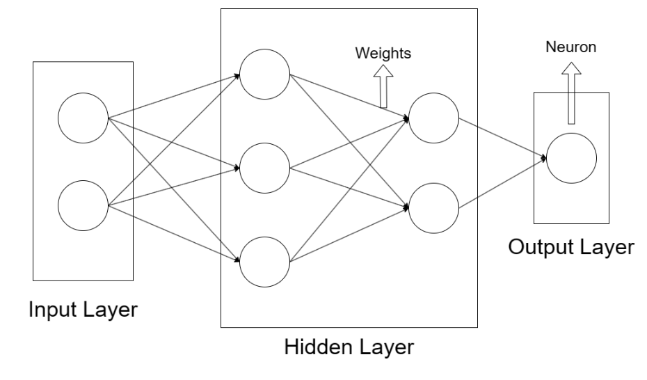

## A. Pembuatan Environment

- Environment adalah tempat / lingkungan dimana library - library python yang akan digunakan diinstal.
- Env bisa dibuat melalui command prompt atau bisa juga di halaman anaconda.

**1. Via command prompt**

Hal pertama yang perlu dilakukan adalah membuka anaconda prompt di masing - masing device. Setelah itu tuliskan: conda create - - name [Nama Env]

a. Langkah Pertama

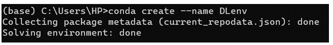

b. Setelah itu pilih "y"

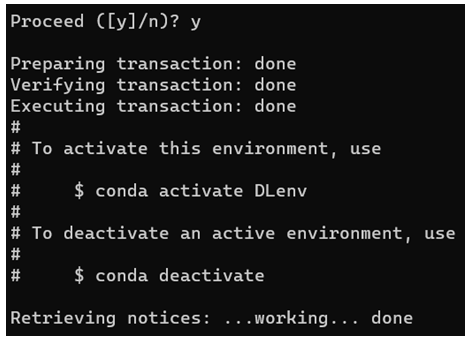

c. Aktivasi Environment Sebelum Instal Library

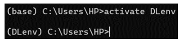

d. Kalau sudah tidak menggunakannya lagi, maka perlu di deactivate dengan cara berikut:

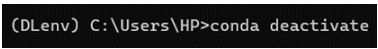

e. Untuk menghapus environment Maka seluruh library yang terinstal dan environment yang dibuat sudah terhapus dan tidak bisa digunakan kembali.

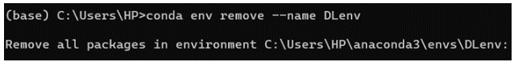

**2. Via halaman Anaconda** a. Tekan Tombol Create

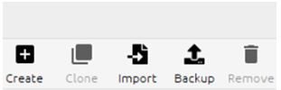

b. Lalu Tekan create

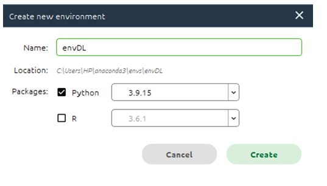

**Environment Terbentuk**

Setelah environment dibuat, maka dilakukan instalasi library - library yang akan digunakan seperti Pandas, Numpy, Matplotlib, Seaborn, Tensorflow, Flask, dan lainnya sesuai kebutuhan.

**Instalasi Library di Environment Baru**

- pip install –upgrade pip
- pip install pandas
- pip install numpy
- pip install tensorflow
- pip install matplotlib

## Pengenalan ANN

Jaringan saraf tiruan, juga dikenal sebagai artificial neural networks, adalah model komputasi yang didasarkan pada struktur dan fungsi otak manusia. Ini terdiri dari neuron, unit kecil yang saling terhubung dengan bobot yang dapat diubah.

Neural network digunakan untuk memproses data, melakukan tugas seperti pengenalan pola, klasifikasi, dan regresi, serta mempelajari pola-pola ini dari data pelatihan.

Lapisan-lapisan neuron memungkinkan neural network untuk mempelajari representasi fitur data yang kompleks. Ini adalah salah satu teknik penting dalam deep learning, yang menggunakan artificial neural networks yang dalam dan kompleks untuk menyelesaikan masalah yang kompleks.

### Perhitungan yang terjadi di dalam ANN

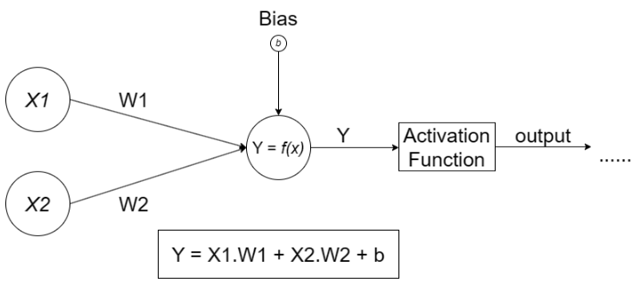

**Komponen Utama Artificial Neural Networks**

1.) Neuron

- Unit dasar dalam ANN yang menerima input, melakukan perhitungan, dan menghasilkan output.
- Input dikalikan dengan bobot yang sesuai dan dijumlahkan.
- Hasilnya kemudian diteruskan melalui fungsi aktivasi.

  2.) Layer (Lapisan)
- Neuron dikelompokkan dalam 3 lapisan yang berbeda: lapisan input, lapisan tersembunyi (hidden), dan lapisan output.
- ANN terdiri dari satu atau lebih lapisan neuron.
- Lapisan input : menerima data masukan
- Lapisan tersembunyi : Membuat representasi fitur internal.
- Lapisan output : Menghasilkan output terakhir

  3.) Weights (Bobot)
- Bobot menghubungkan neuron dalam lapisan yang berbeda.
- Mereka mengontrol seberapa kuat pengaruh suatu neuron terhadap neuron lain.
- Bobot diubah selama proses pelatihan jaringan.

  4.) Activation Function (Fungsi Aktivasi)
- Fungsi yang diterapkan pada output neuron untuk menentukan apakah mereka harus aktif atau tidak.
- Contoh fungsi aktivasi adalah ReLU, sigmoid, dan tanh.
- Mereka memperkenalkan non-linearitas ke dalam model.

**Cara Artificial Neural Networks Bekerja**